# PREVENT-19 Stage 1 Correlates for NVX IgG and ACE2 Assays

## Data descriptive

This dataset adds two NVX assays to the stage 1 dataset and contains both vaccine and placebo arms and seroneg/seropos.

A decision is made to use the same clinical database that was used in the original correlates paper, and not use the updated clinical database. The updated database includes some late changes, e.g. US147-0424 is a case in the new database. For the stage 2 study, we will use the updated clinical database.

There are 1750 subjects with NVX IgG, of which 1710 belong to the original Stage 1 dataset.

```r
mytable(!is.na(dat_raw[,"IGG Day 35"]))
```

```
##
## TRUE
## 1750
```

```r
sum(("2019nCoV301-"%.%dat_raw[,1,drop=T]) %in% dat_mapped$Subjectid)
```

```
## [1] 1710
```

```r
with(subset(dat_mapped, ph1.D35 & Trt==1 & Bserostatus==0 & Country==0), mytable(!is.na(Day35ACE2), !is.na(Day35bindNVXIgG), EventIndPrimaryD1))
```

```
## , , EventIndPrimaryD1 = 0
##
##
##         FALSE  TRUE
##   FALSE 13634     2
##   TRUE      0  1646
##
## , , EventIndPrimaryD1 = 1
##
##
##         FALSE  TRUE
##   FALSE     0     0
##   TRUE      0    12
```

NVX ACE2 was measured on 1708 out of the 1710 subjects with NVX IgG. We will **define ph2 as requiring both IgG and ACE2**.

```r
with(subset(dat_mapped, ph1.D35 & Trt==1 & Bserostatus==0 & Country==0), mytable(!is.na(Day35ACE2), !is.na(Day35bindNVXIgG), EventIndPrimaryD1))
```

```
## , , EventIndPrimaryD1 = 0
##
##
##         FALSE  TRUE
##   FALSE 13634     2
##   TRUE      0  1646
##
## , , EventIndPrimaryD1 = 1
##
##
##         FALSE  TRUE
##   FALSE     0     0
##   TRUE      0    12
```

```r
with(subset(dat_proc, ph1.D35 & Trt==1 & Bserostatus==0 & Country==0), mytable(!is.na(Day35bindSpike), !is.na(Day35ACE2), EventIndPrimaryD1))
```

```
## , , EventIndPrimaryD1 = 0
##
##
##         FALSE  TRUE
##   FALSE 13189  1446
##   TRUE    477   170
##
## , , EventIndPrimaryD1 = 1
##
##
##         FALSE  TRUE
##   FALSE     0     0
##   TRUE      0    12
```

Because the sampling for bindNVXIgG factors in the strata for the subcohort sampling, we will use 1648 non-cases and compute weights

```r
with(subset(dat_proc, ph1.D35 & Trt==1 & Country==0 & Bserostatus==0), mytable(ph2.D35NVX, Wstratum))
```

```
##           Wstratum
## ph2.D35NVX   21   22   23   24   25   26   27   28   43
##      FALSE 4829 3878  490  585 1804 1989   19   72    0
##      TRUE   419  281  144  206  182  175   92  117   12
```

## Immunogenicity

Before censoring with pos cutoff, the minimum marker value is 100 on the antilog scale, which suggests that the lower limit is 200. After censoring at 500, the min is 500 on the antilog scale. The unit is EU (ELISA Unit), which can be divided by 22 to get IU. ULOQ is set to 2,904,275 EU/mL.

```r
10**sort(unique(dat_mapped$BbindNVXIgG))[1:10]
```

```
##  [1] 500 509 537 550 562 574 586 606 612 623
```

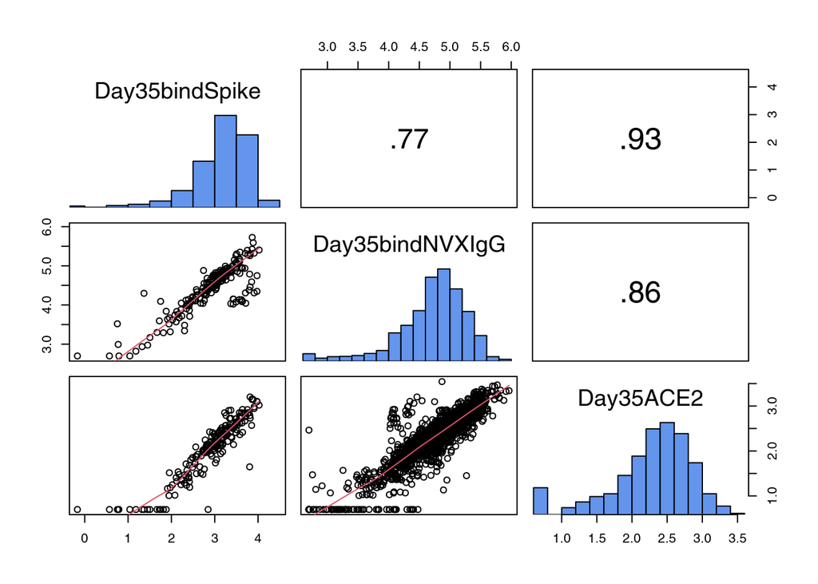

```r
with(subset(dat_mapped, ph1.D35 & Trt==1), mypairs(cbind(Day35bindSpike, Day35bindNVXIgG, Day35ACE2)))
```

The scatterplot shows that the bindNVXIgG readout has some outliers. We define the outliers to be the red dots based on the scatterplot between bindNVXIgG and ACE2. No outliers are cases. The green dots are not defined as outliers although they show larger discrepancy between bindNVXIgG and bindSpike.

```r
# use this version to get dat for outliers study
dat_proc1=read.csv('/trials/covpn/p3004/analysis/correlates/Part_A_Blinded_Phase_Data/adata/prevent19_data_processed_20240313.csv')
dat=subset(dat_proc1, ph1.D35 & Trt==1 & Bserostatus==0 & Country==0)


outliers1 = subset(dat, Day35bindNVXIgG-Day35ACE2 < 1.8 & Day35ACE2 > 2 & Day35bindNVXIgG > 3, Ptid, drop=T)
outliers2 = subset(dat, Day35bindNVXIgG-Day35bindSpike < .9, Ptid, drop=T)
any(subset(dat, EventIndPrimaryD35==1, Ptid, drop=T) %in% outliers1)
```

```
## [1] FALSE
```

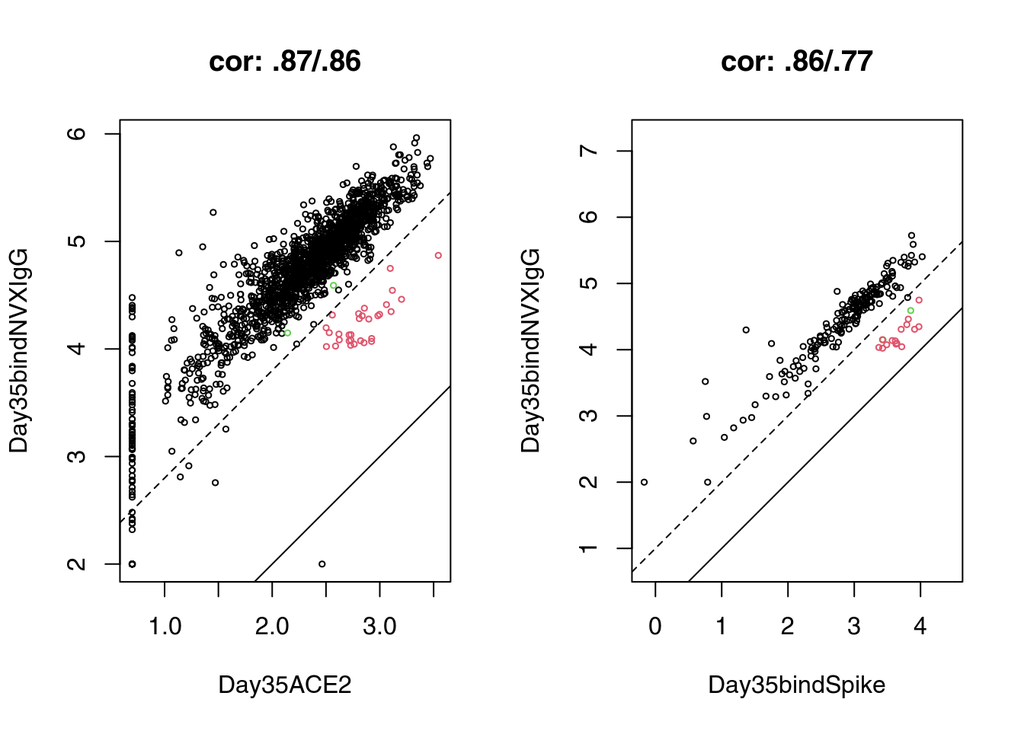

```r
col=ifelse(dat$Ptid %in% outliers1, 2, 1)
col[dat$Ptid %in% outliers2 & col==1]=3

par(mfrow=c(1,2))
corplot(Day35bindNVXIgG~Day35ACE2, dat, col=col, asp=1)
abline(1.8,1, lty=2)
# abline(h=log10(500))

corplot(Day35bindNVXIgG~Day35bindSpike, dat, col=col, asp=1)
abline(1,1, lty=2)
```

The list of outliers

```r
outliers1
```

```
##  [1] "2019nCoV301-US039-0381" "2019nCoV301-US060-0015" "2019nCoV301-US104-0092"
##  [4] "2019nCoV301-US106-0027" "2019nCoV301-US135-0229" "2019nCoV301-US139-0041"
##  [7] "2019nCoV301-US147-0266" "2019nCoV301-US147-0344" "2019nCoV301-US160-0085"
## [10] "2019nCoV301-US160-0192" "2019nCoV301-US162-0247" "2019nCoV301-US164-0113"
## [13] "2019nCoV301-US187-0007" "2019nCoV301-US191-0334" "2019nCoV301-US191-0366"
## [16] "2019nCoV301-US194-0170" "2019nCoV301-US195-0053" "2019nCoV301-US207-0292"
## [19] "2019nCoV301-US215-0081" "2019nCoV301-US215-0109" "2019nCoV301-US215-0218"
## [22] "2019nCoV301-US217-0074" "2019nCoV301-US217-0160" "2019nCoV301-US219-0056"
## [25] "2019nCoV301-US225-0013" "2019nCoV301-US228-0183" "2019nCoV301-US232-0305"
## [28] "2019nCoV301-US235-0031" "2019nCoV301-US242-0004" "2019nCoV301-US245-0116"
```

List of newly tested ptids are highlighted in red below.

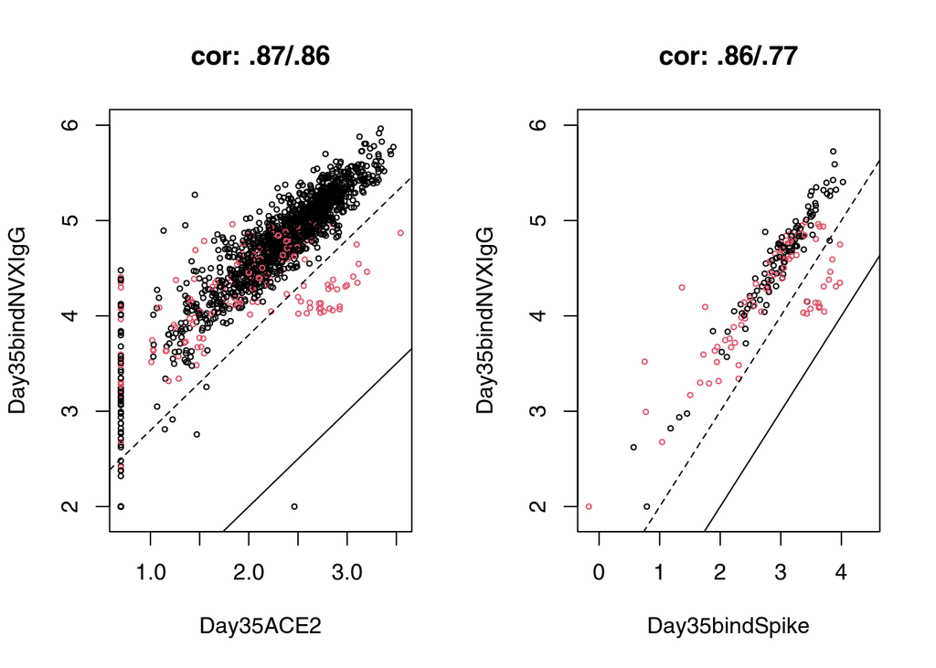

```r
stratum7 = "2019nCoV301-"%.%c("US005-0247","US013-0005","US013-0051","US018-0022","US027-0191","US039-0294","US039-0381","US049-0037","US081-0007","US081-0050","US097-0030","US097-0034","US097-0042","US097-0127","US098-0067","US098-0084","US106-0027","US134-0011","US135-0068","US135-0229","US139-0041","US142-0036","US143-0039","US143-0081","US143-0102","US143-0513","US143-0518","US143-0585","US144-0051","US147-0145","US147-0163","US147-0275","US147-0344","US152-0176","US152-0337","US154-0100","US154-0209","US156-0093","US157-0048","US160-0192","US160-0239","US160-0275","US160-0382","US160-0392","US160-0436","US160-0525","US161-0306","US162-0187","US170-0064","US176-0014","US178-0161","US179-0057","US179-0332","US179-0382","US180-0004","US180-0227","US187-0007","US189-0040","US191-0162","US191-0301","US191-0334","US191-0366","US194-0284","US195-0053","US196-0057","US203-0065","US204-0100","US204-0127","US206-0203","US206-0260","US207-0292","US208-0029","US213-0007","US213-0080","US215-0003","US215-0081","US215-0142","US215-0160","US215-0175","US217-0160","US219-0056","US225-0013","US228-0018","US228-0113","US228-0182","US228-0183","US230-0014","US230-0046","US230-0054","US232-0001","US232-0004","US235-0031","US235-0062","US236-0062","US239-0036","US239-0177","US239-0316","US242-0004","US243-0020","US249-0089")
stratum8 = "2019nCoV301-"%.%c("US005-0018","US005-0272","US039-0004","US039-0081","US047-0105","US049-0219","US060-0015","US060-0138","US081-0042","US097-0009","US097-0021","US097-0031","US097-0040","US104-0092","US134-0084","US135-0010","US135-0158","US142-0018","US142-0021","US142-0041","US142-0060","US142-0064","US142-0117","US143-0233","US146-0107","US147-0266","US152-0183","US154-0020","US154-0123","US154-0222","US156-0002","US156-0013","US156-0145","US157-0045","US160-0037","US160-0085","US160-0477","US160-0506","US160-0555","US161-0272","US162-0247","US163-0039","US163-0041","US164-0113","US166-0010","US168-0348","US172-0008","US172-0031","US176-0006","US176-0027","US176-0028","US176-0034","US178-0252","US179-0068","US188-0053","US191-0048","US191-0099","US191-0144","US191-0246","US194-0170","US194-0219","US196-0378","US203-0016","US203-0039","US204-0027","US204-0103","US204-0138","US205-0131","US205-0145","US206-0286","US208-0247","US211-0005","US211-0008","US211-0063","US215-0026","US215-0027","US215-0109","US215-0112","US215-0218","US217-0074","US217-0143","US217-0266","US218-0017","US219-0060","US225-0030","US231-0148","US232-0026","US232-0208","US232-0245","US232-0305","US239-0078","US239-0242","US239-0251","US239-0309","US240-0061","US242-0027","US242-0040","US244-0039","US245-0078","US245-0116")

col=ifelse(dat$Ptid %in% c(stratum7, stratum8), 2, 1)

par(mfrow=c(1,2))
corplot(Day35bindNVXIgG~Day35ACE2, dat, col=col, ylim=c(1.9,6))
abline(1.8,1, lty=2)

corplot(Day35bindNVXIgG~Day35bindSpike, dat, col=col, ylim=c(1.9,6))
abline(1,1, lty=2)
```

The smallest value of NVX ACE2 is 5, consistent with LOD being 10. The scatterplot between ACE2 and ELISA suggests that ACE2 may be more specific at the low end of the readout.

```r
10**(sort(dat_mapped$Day35ACE2)[1:100])
```

```
##   [1]  5.0  5.0  5.0  5.0  5.0  5.0  5.0  5.0  5.0  5.0  5.0  5.0  5.0  5.0  5.0
##  [16]  5.0  5.0  5.0  5.0  5.0  5.0  5.0  5.0  5.0  5.0  5.0  5.0  5.0  5.0  5.0
##  [31]  5.0  5.0  5.0  5.0  5.0  5.0  5.0  5.0  5.0  5.0  5.0  5.0  5.0  5.0  5.0
##  [46]  5.0  5.0  5.0  5.0  5.0  5.0  5.0  5.0  5.0  5.0  5.0  5.0  5.0  5.0  5.0
##  [61]  5.0  5.0  5.0  5.0  5.0  5.0  5.0  5.0  5.0  5.0  5.0  5.0  5.0  5.0  5.0
##  [76]  5.0  5.0  5.0  5.0  5.0  5.0  5.0  5.0  5.0  5.0  5.0  5.0  5.0  5.0 10.2
##  [91] 10.4 10.7 10.7 10.7 10.7 10.8 11.6 11.7 11.7 12.2
```

Correlation plot between baseline and D35 marker. Without placebo, it is hard to tell the range of non-specific binding.

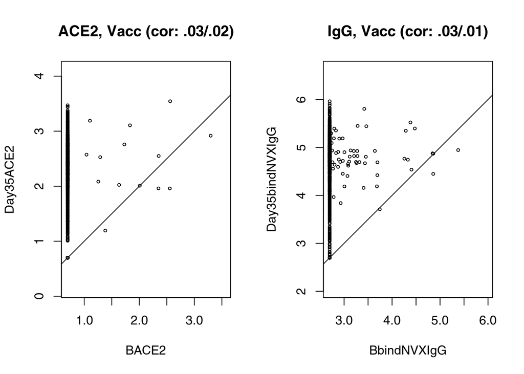

```r
par(mfrow=c(1,2))
lim=range(dat_mapped$Day35ACE2, na.rm=T)
corplot(Day35ACE2~BACE2, dat_mapped[dat_mapped$Trt==1,], xlim=lim, asp=1, main="ACE2, Vacc")
lim=range(dat_mapped$Day35bindNVXIgG, na.rm=T)
corplot(Day35bindNVXIgG~BbindNVXIgG, dat_mapped[dat_mapped$Trt==1,], xlim=lim, asp=1, main="IgG, Vacc")
```

Distributions of sampling weights shows that for the USG markers, stratum 27 and 28 (7 and 8) have weights 2.0 and 2.7, respectively. For the NVX markers, if we exclude the latest batch that contains the outliers, the weights rise to 4.3 and 4.2, respectively.

```r
with (subset(dat_proc, ph1.D35==1 & Trt==1 & Bserostatus==0 & Country==0), table(wt.D35, Wstratum))
```

```
##                   Wstratum
## wt.D35               21   22   23   24   25   26   27   28   43
##   1                   0    0    0    0    0    0    0    0   12
##   2.01818181818182    0    0    0    0    0    0  111    0    0
##   2.73913043478261    0    0    0    0    0    0    0  189    0
##   6.96703296703297    0    0  634    0    0    0    0    0    0
##   9.8875              0    0    0  791    0    0    0    0    0
##   26.8378378378378    0    0    0    0 1986    0    0    0    0
##   29.6438356164384    0    0    0    0    0 2164    0    0    0
##   42.8762886597938    0 4159    0    0    0    0    0    0    0
##   51.4509803921569 5248    0    0    0    0    0    0    0    0
```

```r
with (subset(dat_proc, ph1.D35==1 & Trt==1 & Bserostatus==0 & Country==0), table(wt.D35NVX, Wstratum))
```

```
##                   Wstratum
## wt.D35NVX            21   22   23   24   25   26   27   28   43
##   1                   0    0    0    0    0    0    0    0   12
##   1.20652173913043    0    0    0    0    0    0  111    0    0
##   1.61538461538462    0    0    0    0    0    0    0  189    0
##   3.83980582524272    0    0    0  791    0    0    0    0    0
##   4.40277777777778    0    0  634    0    0    0    0    0    0
##   10.9120879120879    0    0    0    0 1986    0    0    0    0
##   12.3657142857143    0    0    0    0    0 2164    0    0    0
##   12.5250596658711 5248    0    0    0    0    0    0    0    0
##   14.8007117437722    0 4159    0    0    0    0    0    0    0
```